# Introduction to Statistical Learning

Week 1

ADS-STAT 5525 - Statistical Learning

# Module Learning Goals

The goal of this module is for you to

- develop a vocabulary about data, analytics, statistical and machine learning
- understand the “big data” evolution toward data-driven systems
- define and distinguish types of learning, types of insights, types of responses
- distinguish the approaches to data analysis, data mining, machine learning, and statistical learning
- understand the principles and goals of supervised, unsupervised, and reinforcement learning

# Data, Analytics, Decision

## Definitions

**Data:** is information about the world  
**Analytics:** is the process of extracting insight from data  
**Decisioning:** is to choose an action after consideration

In recent decades this relationship has changed fundamentally:

- The amount of available data has exploded
- Our understanding of **data** has evolved
- Our capabilities to perform **analytics** have evolved
- Data and analytics have become the foundation for **decisions**

Data + Analytics = Decision

## Data Evolution

- **Types**
  - **Then** : Single stream/source of structured data
  - **Now** : Rich data types, unstructured data (text, documents, emails, records), audio, video, images, sensor data, ticker data, click streams, geo-spatial data, ...
- **Approach**
  - **Then** : Define the problem, then collect the data
  - **Now** : Examine what the data can tell you
- **Motion**
  - **Then** : Data at rest
  - **Now** : Streaming data, data at rest, data in motion (cloud-data center, multi-cloud, distributed data)
- **Origin**
  - **Then** : Observational studies or designed experiments
  - **Now** : Machine-generated data, large-scale data collections
- **Size**
  - **Then** : KB, MB to GB range, up to 10s of features
  - **Now** : GB - TB - PB table sizes, 1000s of features
- **Others?**

## Big Data

What is Big Data? The term **Big Data** appeared in the 2000s to describe a new class of applications and uses of data.  
The term is unfortunate in that **size** of data sets was only one thing that had changed.  
What had changed? Why a new term?

- The **Now** of data evolution was here
- Begin of **data-driven** applications
- Greater automation of data and model lifecycle

What is Big Data Big data refers to datasets that are too large, complex, or fast-growing to be effectively captured, stored, managed, or analyzed using **traditional** data-processing tools.

**What makes data “big”?**  
It cannot fit in memory on a single machine  
Processing it takes too long with standard methods  
You need distributed storage and computation (e.g., clusters, cloud computing)

**Examples**  
Climate and weather model ensembles  
High-resolution turbulence simulations  
Genomics data  
Web traffic and user behavior logs  
IoT and sensor networks

It’s not just about size—big data is usually described by the “5 Vs”:

1. **Volume:** Massive amounts of data (terabytes, petabytes, or more)  
   Example: satellite observations, climate model outputs, social media logs
2. **Velocity:** Data generated and collected at high speed  
   Example: sensor streams, financial transactions, real-time monitoring systems
3. **Variety:** Different data types and formats  
   Structured: tables, databases  
   Semi-structured: JSON, XML  
   Unstructured: text, images, video, simulation outputs
4. **Veracity:** Data quality and uncertainty  
   Noise, missing values, biases, measurement errors
5. **Value:** The potential to extract useful information or insight  
   Big data is only valuable if it can be turned into knowledge or decisions

## Data-driven Systems

A data-driven system (process or application) is one where the data defines how the system operates. The system has been trained on data and applies implicitly or explicitly derived algorithms to new data in order to provide intelligence and support actions.

- Self-driving vehicles
- Robotic process automation (RPA)
- Ride-sharing
- Social media sites
- Streaming media
- Fraud (anomaly) detection
- Generative AI (ChatGPT)
- Recommendation systems
- Internet of Things (IoT)
- Precision agriculture
- e-commerce

**Example of data-driven system: Churn model**  
Losing a customer is known by different names depending on the industry (attrition, churn, turnover, defection, ...). As a company interacts with its customers it needs to determine whether to offer the customer incentives (loyalty points, discounts, perks, etc.) if it wants to retain the customer.

- What information would you like to collect, what would you like to learn from these data, what would be next?
- What elements in this process are **data**, **analytics**, and **decision**?
- What would this look like in a *data-driven* process?
- What role is played by a **churn model** such as
  $$\Pr(Y=\mbox{churn}|\mbox{customer data}) =
  f(\mbox{customer data})$$

A churn model is not just a model; it is a component of a decision system.

**Pipeline view**  
- Data collection (logs, demographics, billing)  
- Feature engineering  
- Model training & validation  
- Prediction at scale  
- Decision/action layer

**Example actions driven by churn predictions**  
- Targeted retention offers depending on customer profile  
- Personalized messaging  
- Pricing incentives  
- Customer success outreach

Churn modeling illustrates key principles of data-driven systems:

**Feedback loops**  
- Interventions affect future churn  
- Models must adapt over time  
**Concept drift**  
- Customer behavior changes  
- Products and markets evolve  
**Cost-sensitive learning**  
- False negatives (missed churners) are expensive  
- False positives waste incentives  
**Interpretability vs performance**  
- Business users often require explanations  
- Tradeoff between black-box models and trust

**Example of data-driven system: Self-driven cars**  
Discuss the differences in how data are used in a late-model car and in a (nearly) autonomous vehicle.

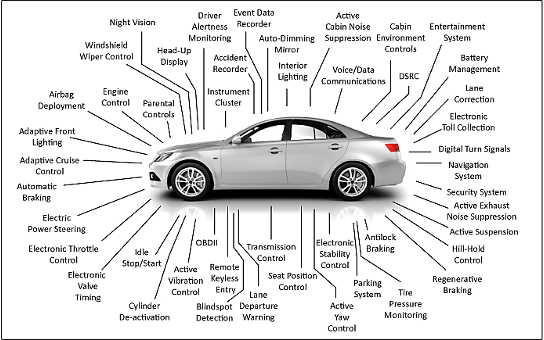

[figure not shown]

Late model (computerized) VS Autonomous (Data-driven system)

## Data: Sources, Analysis and Challenges

### Data Analysis

The term **Data Analysis** was introduced by John W. Tukey in 1962.  
In 1977, Tukey published the seminal book “Exploratory Data Analysis” that defined the field of EDA.  
Tukey’s approach was revolutionary, in that

- much of statistical work was **confirmatory**, based on the concept of a data-generating mechanism
- he placed the data itself at the center, not the generating mechanism
- much can be learned by working with the data itself
- the data can suggest hypotheses
- data analysis can precede probability-based models
- we should be looking for novelty in data analysis

### Data Analysis VS Classical Stats

Tukey contrasted the Data Analysis approach in particular with statistical modeling.

- **Modeling**
  - identify a probability-based model that serves as an abstraction of the data-generating mechanism
  - observed data are seen as one realization of this random mechanism
  - find functions of the data that provide good estimates of the unknown model parameters
  - calculate the parameter estimates and use them to test hypotheses and-or make predictions
- **Data Analysis**
  - identify a particular function of the data
  - make progress by asking what the function might be reasonably estimating

### Sources of Data

Various sources of data with different *characteristics*, *error* and *uncertainty*: measurements, machine-generated data, large-scale data collections, ... **Data are a proxy to underlying true process**

- **Computer simulations:** e.g. physics-based model outputs (physically consistent; regularly available; but subject to modeling choices and approximations)
- **Observations, measurements:** no modeling assumptions but measurement errors, irregularly sampled and sparse; e.g. weather stations, satellite data, floating buoys, citizen science, …

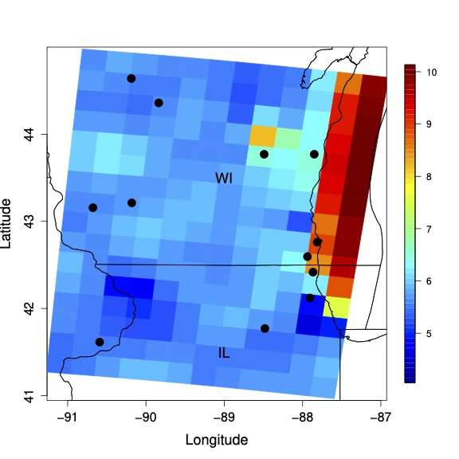

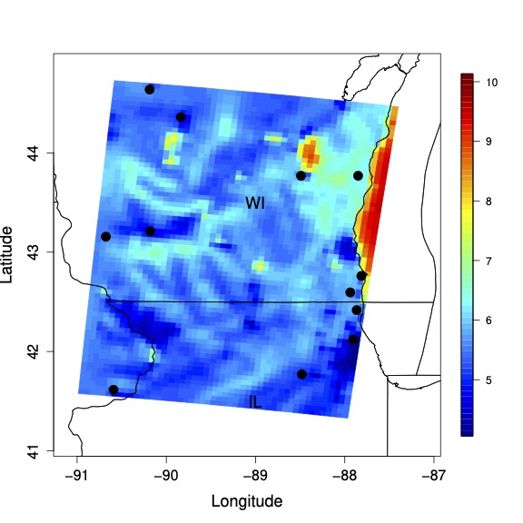

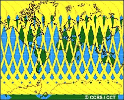

Examples of numerical weather prediction models (low and high resolutions, **Weather Research and Forecasting model, NCAR**) and satellite data coverage (**Natural Resources Canada**)

### Data Challenges

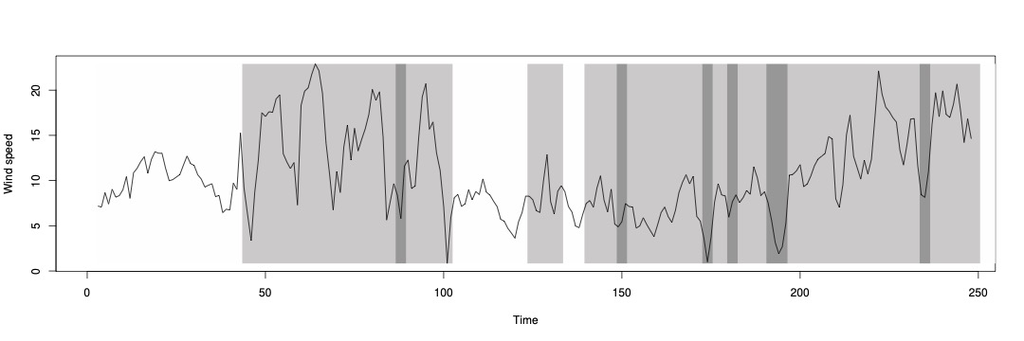

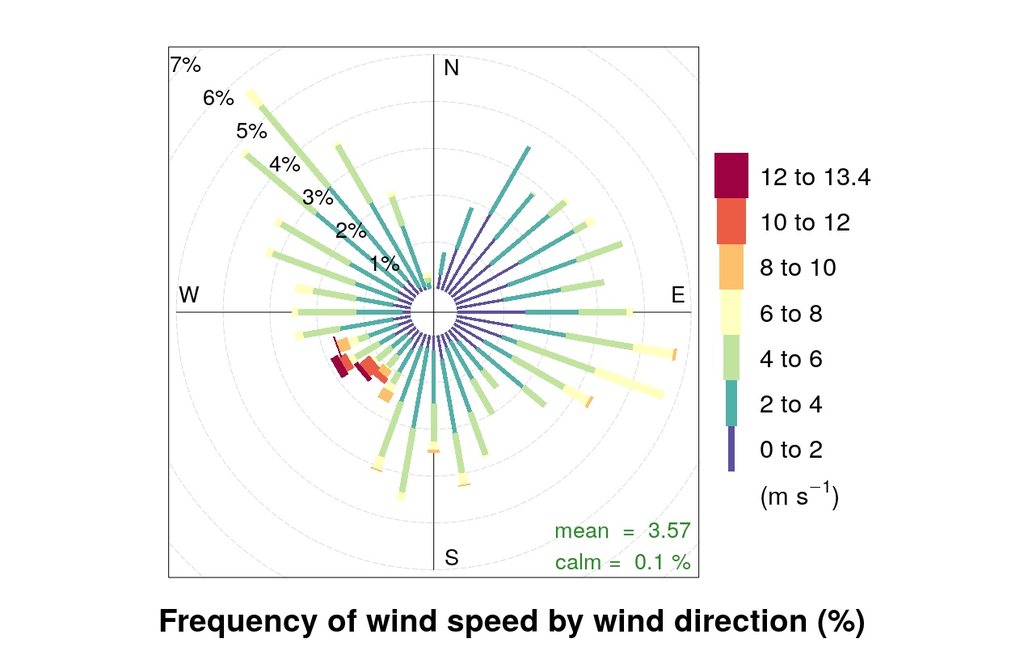

Left: Regimes (shaded intervals) in a time series; Right: Windrose of wind speed and direction

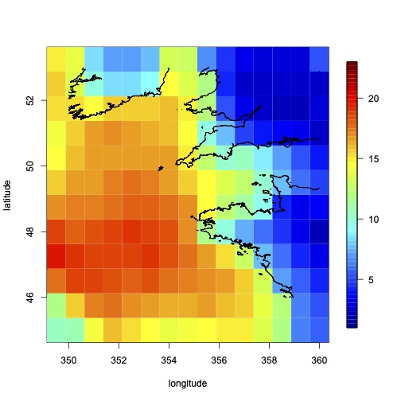

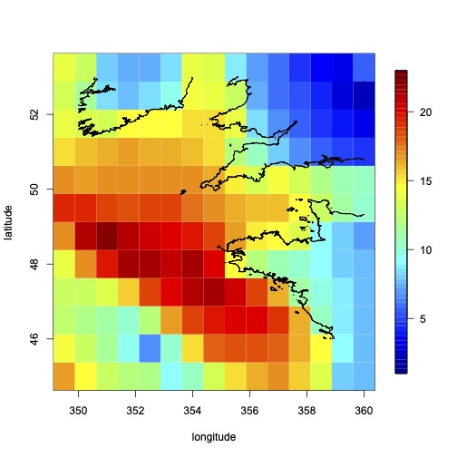

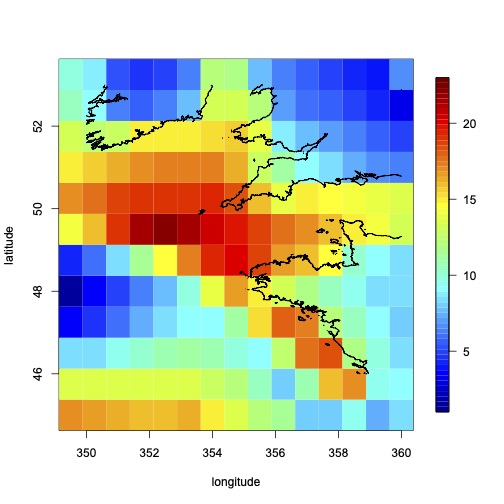

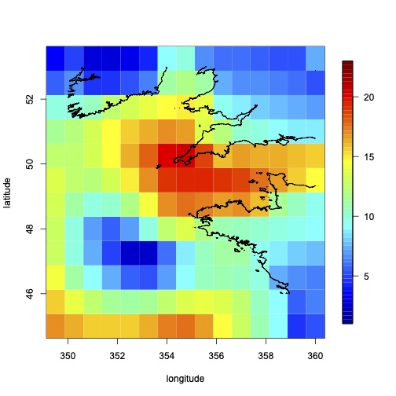

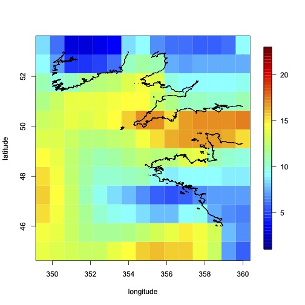

Propagation of a wind storm

$\rightarrow$ need to adapt analysis, models and techniques to these challenges

### Types of Relationships

- **Causal**: one event is the result of the occurrence of the other event, also referred to as cause and effect.  
  Example: $A \Rightarrow B$. Smoking causes an increase in the risk of lung disease
- **Correlation**
  - **Dependence**: variables are related to each other without causing each other  
    Example: The weight of mammals is correlated with their height  
    Example: Smoking correlates with alcoholism but does not cause it
  - **Spurious**: the relationship is due to latent (confounding) or mediating variables.  
    Example: $A \Rightarrow B, A \Rightarrow C$. $B$ and $C$ appear correlated. Warmer temperature increases ice cream sales and trips to the beach: ice cream sales and shark attacks are positively correlated.  
    Example: $A \rightarrow B \rightarrow C$. $A$ is related to $B$ and $B$ is related to $C$. If you observe only $A$ and $C$ they appear correlated. Parental education level ($B$) is the mediator between socioeconomic status ($A$) and child reading ability ($C$)

### Spurious Correlation

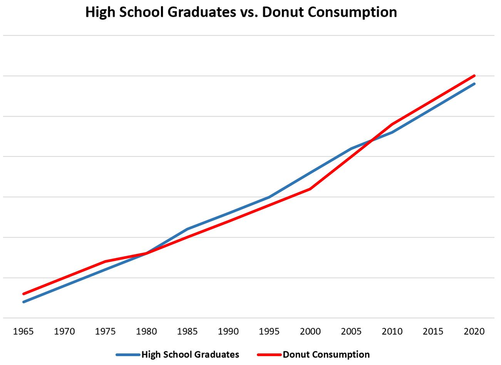

Example of spurious correlation

Source: [Statology](https://www.statology.org/spurious-correlation-examples/)

Check [this site](https://tylervigen.com/spurious-correlations) for many examples of spurious temporal correlations.

### Survivorship on the Titanic

Tukey defined the **boxplot** as a way to visualize the distribution of data. These box plots are computed from passenger data of the Titanic.  
Which questions and hypotheses do they answer/suggest?

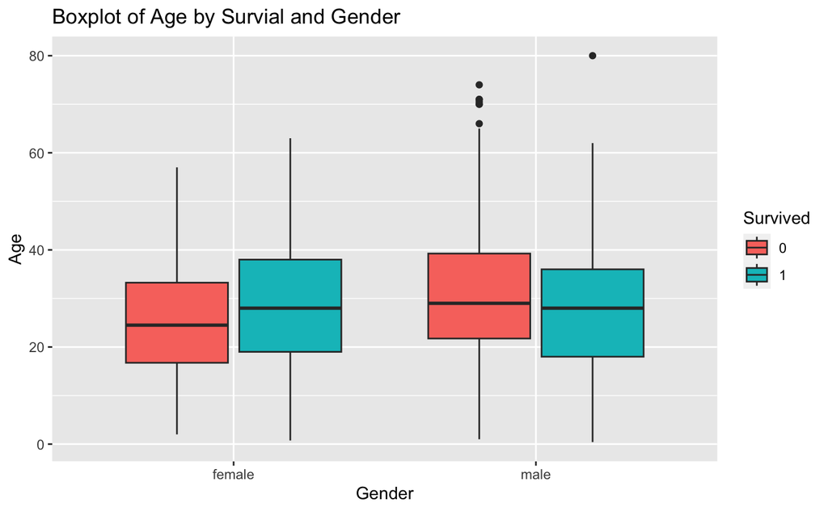

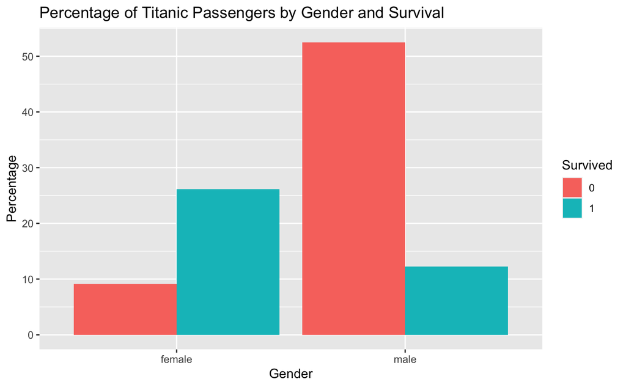

Titanic data

Which questions or hypotheses do these histograms answer/suggest?

# Methods of Analysis–from Statistics to ML to AI

## Introduction to statistical modeling

- **Goals:** characterize, predict, classify and simulate phenomena in many fields e.g. ecology, epidemiology, meteorology, medicine, finance, industry …

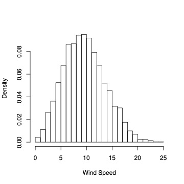

Wind speed probability distribution

### Methods of Analysis

- In Tukey’s approach we recognize the beginnings of EDA, Data Mining, and Machine Learning.
- Our understanding of **Data Analytics** is encompassing. It includes elements of Statistical Modeling, Statistical Learning, Machine Learning, Data Mining, etc.
- Sometimes we will be led more by the data, sometimes we will be led more by a model that captures the salient features of the data.

**Classical Statistics:** tests hypotheses and makes predictions based on a probability-based model that explains the data

**Statistical Learning:** was introduced by Hastie & Tibshirani.  
Very much model-based but with a focus on prediction vs hypothesis testing  
More recently, statistical models used to simulate/surrogate

**Data Mining:** searches large datasets for trends and patterns using computer automation.

**Machine Learning:** programs computers (machines) so that they will learn.

### General Concepts

- **Types of Insights**
  - **Descriptive**: What has happened?
  - **Predictive**: What will happen?
  - **Classification**: Which category does this belong to?
  - **Clustering**: Which groups/categories exist?
  - **Prescriptive**: What should I do?
- **Online vs Batch**
  - **Online**: the learner responds online during the training process–real time
  - **Batch**: data are at rest and analyzed as a set

### Types of Learning

- **Supervised**:
  - Data are “labeled”, “labeled” meaning each piece of input data is provided with the correct output,  
    Algorithm learn to map input data to a specific output based on example input-output pairs.
  - Goal of supervised learning is for the trained model to accurately predict the output for new, unseen data. This requires the algorithm to effectively generalize.
  - Commonly used for tasks like classification (predicting a category, e.g., spam or not spam) and regression (predicting a continuous value, e.g., house prices).
- **Unsupervised**:
  - Data are not “labeled”, the model identifies patterns or structures in unlabeled data (no input-output pairs).
  - Examples of unsupervised techniques: clustering algorithms like k-means, dimensionality reduction techniques like principal component analysis (PCA)

### Response (Variable) Types

- **Continuous**: The number of possible values is not countable  
  (tire pressure, temperature, length, weight, ...)
- **Discrete**: The number of possible values is countable
  - **Counts**: The values are true counts  
    *Count per unit*: (# of fish caught today, # of bike rentals per hour)  
    *Proportions*: count out of a total (# of larvae died out of 20)
  - **Categorical**: The values consist of labels, possibly numbers  
    *Nominal*: Unordered labels (“Apples”, “Oranges”, “Bananas”)  
    *Ordinal*: Ordered labels (Reviews: 1-5 stars)  
    *Binary*: Exactly two labels (Dead/Alive, Fraud/Not-Fraud, 0/1, Yes/No)

## Statistical Learning

**Statistical Learning** is the process of understanding data through the application of tools that describe structure and relationships in data.  
Models are formulated based on the structure of data to **predict** outputs from inputs, to **group** data, or to **reduce** the dimensionality of a problem.

- SL combines mathematical statistics and statistical modeling with greater emphasis on predicting rather than testing hypotheses
- SL emphasizes models and their interpretability, precision, and uncertainty.
- SL distinguishes **supervised** and **unsupervised** learning, depending on whether the values (the labels) of the response variable are known.
- **Supervised Learning**
  - The response variable (output, target, dependent) is observed along with a number of input variables (features, independent variables)
  - The goal is to predict or classify the response variable and to quantify the uncertainty in parameter estimates and predictions.
  - Models (examples)
    - Linear models
    - Nonlinear models
    - Nonparametric models
    - Generalized linear models (GLM), generalized additive models (GAM)
    - Discriminant analysis
    - Mixed Models
    - Tree-based models
    - Neural networks
    - ...

## Data Mining

**Data mining** is the process of searching large data sets for trends and patterns using computer automation. As data sets grow, the type of exploratory discovery in the sense of Tukey can no longer be done manually.

- Data mining relies on compute power and automation to find patterns in data at scale.
- DM focuses on patterns discovered from data rather than model theory and prediction.
- Data mining is about discovering useful, non-obvious patterns or structures in data, often without a predefined response variable.
- Critics of data mining refer to it as “data dredging” or “data fishing”: looking for patterns and relationships that are meaningless and then forming hypotheses about why the patterns exist.

**Example 1: Customer segmentation (clustering)**  
Unsupervised, very common in industry

- Data:
  - Age
  - Income
  - Spending score
  - Number of purchases
- Data mining task:
  - Group customers into segments (e.g., “low spenders",”loyal customers", “untapped potentials")
- Techniques:
  - K-means
  - Hierarchical clustering
- What is mined:
  - Natural groupings not labeled in advance

**Example 2: Anomaly (fraud) detection**  
Pattern discovery through rarity

- Data:
  - Credit card transactions
  - Electricity consumption
  - Network traffic
- Data mining task:
  - Identify unusual behavior compared to the bulk of data
- Techniques:
  - Distance-based outliers
  - Isolation Forest
  - Simple z-score rules
- Easy example:
  - A household suddenly consumes 10 times its usual electricity $\rightarrow$ anomaly

## Machine Learning

**Learning** is the process of converting experience into knowledge.  
**Machine Learning** is an automated way of learning through the use of computers.  
Rather than directly programming computers to perform a task, ML is used when the tasks are not easily described and communicated (driving, reading, image recognition) or when the tasks exceed human capability (analyzing large and complex data sets).

- ML is a branch of artificial intelligence (AI) as it is using computers to turn experience into expertise (knowledge)
- Origin of modern ML: Computer Science discovered data as a source for computational considerations
- Like Data Mining, ML uses automation to extract insight from large data sets. The focus of automation in developing ML algorithms is to predict, classify, or make recommendations. Data Mining tends to be more descriptive than predictive.
- **Supervised Learning**
  - The training example contains significant information (“labels" (i.e. outputs) for the target variable, the”ground truth”) that might not be present in the test example.
  - The goal is to predict or classify the missing information in the test data. We want to learn the outputs from the inputs.
  - We can think of the environment as a teacher that “supervises” the learner by providing information about the truth.
  - Algorithms (examples)
    - Linear regression (simple & multiple)
    - Regularized regression (Ridge & Lasso)
    - Logistic regression
    - Support-vector machines
    - Gradient boosting
    - Decision trees, Random Forests
    - Neural networks (CNN, RNN, LSTM, ...)
    - Transformer (NLP, CV)
- **Unsupervised Learning**
  - There is no target variable we wish to predict or classify. We still want to learn relationships and structure from the data.
  - Clustering data into similar groups or reducing the dimension of the data are typical uses for unsupervised learning.
  - Algorithms (examples)
    - Clustering  
      K-nearest neighbors  
      Hierarchical clustering  
      K-means clustering  
      Association rules learning
    - Dimensionality reduction  
      Principal Component Analysis (PCA)  
      Matrix Factorization
- **Reinforcement Learning**
  - An **agent** (player) is taking **actions** (moves) in an **environment** (game)
  - The agent learns by interacting with the environment and receiving feedback
  - Actions are judged by a reward function (score), and the system is trained to maximize the sum of all future rewards
  - Unlike supervised learning, input and output (target) do not need to be present
  - Commonly used in robotics, game playing, and recommendation systems.

## SL & ML Compared

### Statistical Learning & Machine Learning

- **Common**
  - the input to a learning algorithm is training data, representing “experience”. The *raw material* for SL and ML is the same: data.
  - the data are thought of as randomly generated
  - both disciplines distinguish supervised and unsupervised learning, ML also has reinforcement learning
  - SL and ML use many of the same models and algorithms for regression, classification, clustering, dimension reduction
- **Differences**
  - ML uses the observed data to come up with a description of relationship and “causes”. Emphasis is on prediction over explanation (e.g., hypothesis testing)
  - ML emphasizes large scale applications and prediction accuracy.  
    SL emphasizes models, interpretability, precision and uncertainty.
  - SL is concerned with **asymptotic** behavior of parameter estimates, e.g. as ($n \rightarrow \infty$).  
    ML focuses on **finite sample** bounds: what is the degree of accuracy expected on the basis of available samples.
  - ML worries more about algorithms than SL. ML develops algorithms for learning tasks and considers their computational efficiency.
  - SL often works from assumptions of the data model (independence, equi-variance, linearity of effects).  
    ML assumes as little as possible about the distribution of the data.
  - SL is more **model oriented**: what models are available to predict the expected value of a binary random variable?  
    ML is more **task oriented**: given this set of data with a binary target variable, which methods are available to predict or classify the target?

### Statistical Learning & Machine Learning

- Combine the best of both worlds!
- Quantify uncertainty (precision) **and** accuracy for given samples
- Statisticians:
  - worry a bit more about algorithms and computational efficiency
  - worry a bit more about generalization of models to new data
- Machine Learners:
  - worry a bit more about the effects of violating assumptions.  
    (e.g., it is easy not to make distributional assumptions, but what are the implications of lack of independence of observations?)

### Artificial Intelligence

Artificial Intelligence (AI) is the effort to build systems that can perform tasks or make decisions a human could make. AI draws on many disciplines, e.g., robotics, process automation, biology, neuroscience, cognitive science, computer science.

The current form of AI–which is much more successful than attempts in previous decades–differs from past approaches in its reliance on **data**.  
Data-driven AI uses analytic techniques to develop algorithms that can perform human tasks.

Its success was enabled by the confluence of three factors:

- Advances in neural network technology (CNN, RNN, Generative networks, transformers, ...)
- Large data sets made it possible to design deep neural networks (deep learning)
- Cloud computing and GPUs made computing resources accessible to train these deep networks